# Data Visualization

Kemp Po

# *Intro*

*This dashboard will cover several topics on R:*

- *Reading data*
- *Manipulating data*
- *Creating visualizations using the `ggplot2` package*

> *At this point in time, use tidyverse packages Tidyverse includes the usual analytics packages like `ggplot2`, `dplyr`, `readr`, and many other packages that make our lives easier.*

# *Importing Data*

## *Flat files*

### *Text File*

```r
write_lines("Hello World", "data/example.txt")
read_lines("data/example.txt")
```

### *Comma Separated Values*

```r
library(readr)
write_csv(iris, "data/iris.csv")
read_csv("data/iris.csv", show_col_types = FALSE)
```

### *Excel Files*

```r
library(readxl)
readxl::read_excel
```

## *Databases (DBI)*

```r
library(DBI)
library(RPostgres)

dwh_conn <- db_connect(
  drv = Postgres(),
  host = Sys.getenv("DWH_HOST"),
  user = Sys.getenv("DWH_USER"),
  pass = Sys.getenv("DWH_PASS"),
  port = 5432,
  dbname = Sys.getenv("DWH_NAME")
)

dbGetQuery(
  conn = dwh_conn,
  statement = "SELECT * FROM dim_client limit 10"
)

dbExistsTable(
  conn = dwh_conn@con,
  name = "fact_trade_underwriting"
)

dbReadTable(
  conn = dwh_conn,
  name = "fact_fx_rate"
)

dbListTables(
  conn = dwh_conn
)

library(dbx)
library(tibble)

dbDisconnect(
  conn = dwh_conn
)
```

### *Databases (ORM)*

```r
library(dbplyr)
library(dplyr)

tbl(dwh_conn, "dim_client") %>%
  select(revenue_estimate) %>%
  filter(is.na(revenue_estimate)) %>%
  collect(n = Inf)
```

## *Web APIs*

```r
library(httr)
library(dplyr)
library(jsonlite)

GET(
  url = "http://api.exchangeratesapi.io/v1/",
  path = "latest",
  query = list(access_key = Sys.getenv("FX_API_KEY"))
) %>%
  stop_for_status() %>%
  content(as = "parsed") ->
  response

response$rates$USD
```

# *Data manipulation*

*Let’s take a look at our data*

```r
data <- read_csv("data/country vaccinations.csv", show_col_types = FALSE)

ph_data <-
  data %>%
  filter(country == "Philippines")

ph_data %>% head(10)
```

| country | iso_code | date | total_vaccinations | people_vaccinated | people_fully_vaccinated | daily_vaccinations_raw | daily_vaccinations | total_vaccinations_per_hundred | people_vaccinated_per_hundred | people_fully_vaccinated_per_hundred | daily_vaccinations_per_million | vaccines | source_name | source_website |
| --- | --- | --- | --- | --- | --- | --- | --- | --- | --- | --- | --- | --- | --- | --- |
| Philippines | PHL | 2021-02-28 | 0 | 0 | NA | NA | NA | 0.00 | 0.00 | NA | NA | Johnson&Johnson, Moderna, Oxford/AstraZeneca, Pfizer/BioNTech, Sinovac, Sputnik V | Department of Health via ABS-CBN Investigative and Research Group | https://news.abs-cbn.com/spotlight/multimedia/infographic/03/23/21/philippines-covid-19-vaccine-tracker |
| Philippines | PHL | 2021-03-01 | 756 | 756 | NA | 756 | 756 | 0.00 | 0.00 | NA | 7 | Johnson&Johnson, Moderna, Oxford/AstraZeneca, Pfizer/BioNTech, Sinovac, Sputnik V | Department of Health via ABS-CBN Investigative and Research Group | https://news.abs-cbn.com/spotlight/multimedia/infographic/03/23/21/philippines-covid-19-vaccine-tracker |
| Philippines | PHL | 2021-03-02 | 2793 | 2793 | NA | 2037 | 1396 | 0.00 | 0.00 | NA | 13 | Johnson&Johnson, Moderna, Oxford/AstraZeneca, Pfizer/BioNTech, Sinovac, Sputnik V | Department of Health via ABS-CBN Investigative and Research Group | https://news.abs-cbn.com/spotlight/multimedia/infographic/03/23/21/philippines-covid-19-vaccine-tracker |
| Philippines | PHL | 2021-03-03 | NA | NA | NA | NA | 2132 | NA | NA | NA | 19 | Johnson&Johnson, Moderna, Oxford/AstraZeneca, Pfizer/BioNTech, Sinovac, Sputnik V | Department of Health via ABS-CBN Investigative and Research Group | https://news.abs-cbn.com/spotlight/multimedia/infographic/03/23/21/philippines-covid-19-vaccine-tracker |
| Philippines | PHL | 2021-03-04 | 10000 | 10000 | NA | NA | 2500 | 0.01 | 0.01 | NA | 23 | Johnson&Johnson, Moderna, Oxford/AstraZeneca, Pfizer/BioNTech, Sinovac, Sputnik V | Department of Health via ABS-CBN Investigative and Research Group | https://news.abs-cbn.com/spotlight/multimedia/infographic/03/23/21/philippines-covid-19-vaccine-tracker |
| Philippines | PHL | 2021-03-05 | NA | NA | NA | NA | 3514 | NA | NA | NA | 32 | Johnson&Johnson, Moderna, Oxford/AstraZeneca, Pfizer/BioNTech, Sinovac, Sputnik V | Department of Health via ABS-CBN Investigative and Research Group | https://news.abs-cbn.com/spotlight/multimedia/infographic/03/23/21/philippines-covid-19-vaccine-tracker |
| Philippines | PHL | 2021-03-06 | 25138 | 25138 | NA | NA | 4190 | 0.02 | 0.02 | NA | 38 | Johnson&Johnson, Moderna, Oxford/AstraZeneca, Pfizer/BioNTech, Sinovac, Sputnik V | Department of Health via ABS-CBN Investigative and Research Group | https://news.abs-cbn.com/spotlight/multimedia/infographic/03/23/21/philippines-covid-19-vaccine-tracker |
| Philippines | PHL | 2021-03-07 | 29266 | 29266 | NA | 4128 | 4181 | 0.03 | 0.03 | NA | 38 | Johnson&Johnson, Moderna, Oxford/AstraZeneca, Pfizer/BioNTech, Sinovac, Sputnik V | Department of Health via ABS-CBN Investigative and Research Group | https://news.abs-cbn.com/spotlight/multimedia/infographic/03/23/21/philippines-covid-19-vaccine-tracker |
| Philippines | PHL | 2021-03-08 | 44000 | 44000 | NA | 14734 | 6178 | 0.04 | 0.04 | NA | 56 | Johnson&Johnson, Moderna, Oxford/AstraZeneca, Pfizer/BioNTech, Sinovac, Sputnik V | Department of Health via ABS-CBN Investigative and Research Group | https://news.abs-cbn.com/spotlight/multimedia/infographic/03/23/21/philippines-covid-19-vaccine-tracker |
| Philippines | PHL | 2021-03-09 | 89077 | 89077 | NA | 45077 | 12326 | 0.08 | 0.08 | NA | 112 | Johnson&Johnson, Moderna, Oxford/AstraZeneca, Pfizer/BioNTech, Sinovac, Sputnik V | Department of Health via ABS-CBN Investigative and Research Group | https://news.abs-cbn.com/spotlight/multimedia/infographic/03/23/21/philippines-covid-19-vaccine-tracker |

*I’m seeing a lot of NAs. Let’s turn them into 0s instead so we can properly visualize them later. Although, 0 != NA logically.*

```r
# replace NA value with 0
ph_data %>%
replace(is.na(.), 0)

# there's other ways of doing this such as
ph_data %>%
  mutate(total_vaccinations = replace_na(total_vaccinations, 0))
```

> Caveat: there are different scenarios for doing this one-by-one vs programmatically. Know your data first and figure out what type of strategy you would employ.

[output not shown]

[output cut: 149 more lines]

# *Visualization*

## Key Principles:

### Audience Centric

- The first step to visualizing your data will always be answering the question “What story am I trying to tell?” and “who am I talking to?”
- These questions inform us of how to structure our visualizations and what the right level of information is Ex. most of the time company-level metrics don’t need granular information

### KISS (Keep it simple, stupid)

- A very important design principle, also for software.
- Make it easy to understand. Simple = More. The point of visualizations is to make the information as easily digestible as possible.

### Use the right charts

- Choose the graph based on the kind of data and the message
- Different types of graphs convey certain types of information better Ex. line charts are better for showing trends over time than bar graphs
- *Don’t* forget to label your charts properly

### Resources

- [The laws of shitty dashboards](https://www.bears-repeating.com/the-laws-of-shitty-dashboards) put in a very light-hearted manner how *not* to build dashboards and something to always take note of.
- [TJ Palanca: On Data Visualization Design](https://tjpalanca.com/posts/2017-02-05-wiad-2016-talk/)

## Let’s give it a try

### Vaccinations over time

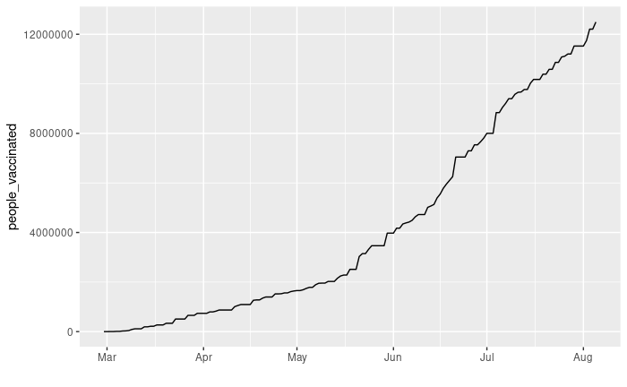

```r
options(scipen=999)

ph_data %>%
  arrange(date) %>%
  fill(people_vaccinated) %>%
  ggplot(aes(x=date, y=people_vaccinated)) +
  geom_line() +
  xlab("")
```

### How is the Philippines faring compared to the rest of ASEAN?

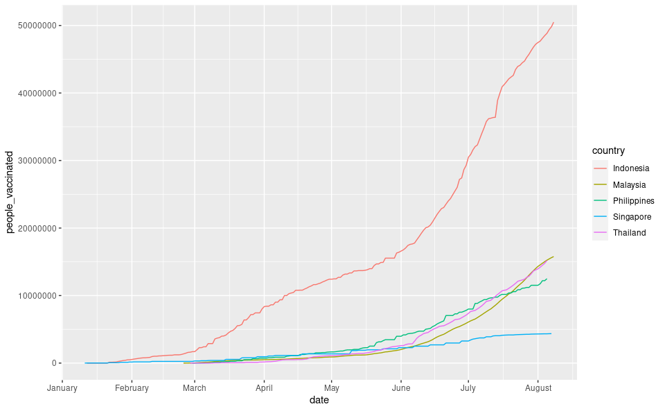

Now you may think, wow the Philippines isn’t doing that bad according to this graph. But you have to remember these are raw numbers. The Philippines has almost 20x the population of Singapore.

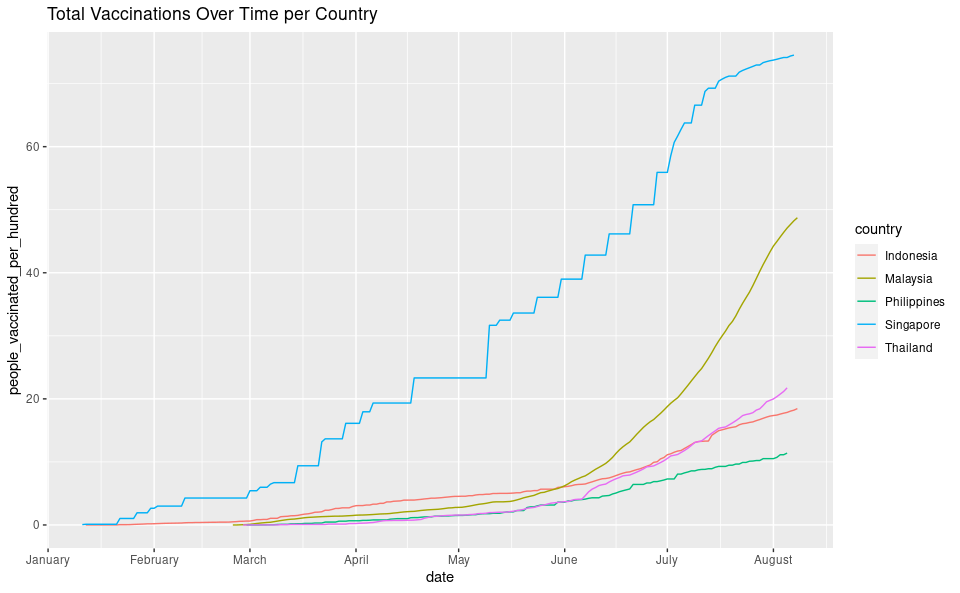

```r
data %>%
  filter(
    country %in% c("Philippines", "Indonesia", "Malaysia", "Singapore", "Thailand")
  ) %>%
  fill(people_vaccinated_per_hundred) %>%
  ggplot(aes(x=date, y=people_vaccinated_per_hundred, group=country, color=country)) +
  geom_line() +
  scale_x_date(date_breaks = "months", date_labels = "%B") +
  ggtitle("Total Vaccinations Over Time per Country")
```